# Rbasic

WANG

2018年1月18日

# R 安裝與簡介

[案我下載](https://oscar82722.github.io/test/r_introduction.pptx)

# 1.R 語言基礎(The Basic of R)

## 1.1.命名規則(naming conventions)

- ‘A’ and ‘a’ 是不一樣的
- 無法以數字與特殊符號當開頭，除了 ‘.’
- 可以使用 ‘.’ , ’_‘ 但 ’@‘ , ’!‘ , ’#‘ , ’%’ 等符號無法使用

**例子:**

- 錯誤命名
  - 3x
  - 3_x
  - x-3
  - .3x
- 正確命名
  - x_3
  - x3
  - x.3
  - taiwan.taipei.x3
  - .x3

## 1.2定義變數(defines variable)

```r
x <- 3
y=5
x
```

```
## [1] 3
```

```r
y
```

```
## [1] 5
```

```r
z
```

```
## Error in eval(expr, envir, enclos): 找不到物件 'z'
```

```r
x <- 4; y <- 5
x;y;
```

```
## [1] 4
```

```
## [1] 5
```

**“#” 為註解，後面輸入的東西並不會顯示**

```r
x <- 4+5 #y=5+5
x;y;
```

```
## [1] 9
```

```
## [1] 5
```

```r
x <- 4+5
y <- 9/3
z <- x+y
x;y;z;
```

```
## [1] 9
```

```
## [1] 3
```

```
## [1] 12
```

## 1.3數值處理(numerical processing)

- round(x,digits = 0) 四捨五入

?round()

```r
x <- 10/3;x
```

```
## [1] 3.333333
```

```r
round(x,digits = 0)
```

```
## [1] 3
```

```r
round(x)
```

```
## [1] 3
```

```r
round(x,digits=3)
```

```
## [1] 3.333
```

```r
y <- 111;round(y,-2)
```

```
## [1] 100
```

1. ceiling(x)， 比 x 大的最小整數。
2. floor(x)，比x 小的最大整數。
3. trunc(x)，把小數點刪掉。

```r
x; ceiling(x); floor(x); trunc(x);
```

```
## [1] 3.333333
```

```
## [1] 4
```

```
## [1] 3
```

```
## [1] 3
```

```r
x <- -1.5; ceiling(x); floor(x);trunc(x);
```

```
## [1] -1
```

```
## [1] -2
```

```
## [1] -1
```

### 練習(1)

令 z 等於 122333，對 z 無條件捨去到百位數及無條件進位到百位數。

(提示:利用ceiling 與 floor ，但需要對數字做一些變化)

```
## z 無條件進位到百分位為: 122400
```

```
## z 無條件捨去到百分位為: 122300
```

## 1.4向量(vector)

由 c() 所構成，利用“,” 做分隔。 讀取向量元數時用 “[]” 。

```r
x1 <- c(1,5,7,8,9); x1
```

```
## [1] 1 5 7 8 9
```

```r
x1[1];x1[2]
```

```
## [1] 1
```

```
## [1] 5
```

```r
x2 <- c(x1,2); x2
```

```
## [1] 1 5 7 8 9 2
```

```r
x3 <- c(2,x1); x3
```

```
## [1] 2 1 5 7 8 9
```

```r
x4 <- c(1:5); x4
```

```
## [1] 1 2 3 4 5
```

```r
x5 <- c(1.5:6); x5
```

```
## [1] 1.5 2.5 3.5 4.5 5.5
```

```r
length(x1)
```

```
## [1] 5
```

```r
x6 <- c(3,x1,"hi");x6
```

```
## [1] "3"  "1"  "5"  "7"  "8"  "9"  "hi"
```

```r
x1 <- c(1,3,5,7,9)
y1 <- x1/3; y1
```

```
## [1] 0.3333333 1.0000000 1.6666667 2.3333333 3.0000000
```

```r
v1 <- x1+y1+1; v1;
```

```
## [1]  2.333333  5.000000  7.666667 10.333333 13.000000
```

```r
x2 <- c(1,3,5);x3 <- c(2,4);
```

### 向量運算(Vector Arithmetic)

- 一些簡單的數學運算
  - +,-,*,/,^
  - log(x), log(x,b)
  - pi, exp(x)
  - abs(x),sqrt(x) sum(x)
- 一些簡單的統計運算
  - max(x),min(x)
  - range(x)
  - mean(x)， var(x)，sd(x)
  - median(x)

```r
a <- c(4,2,-2);
a^2
```

```
## [1] 16  4  4
```

```r
a^3
```

```
## [1] 64  8 -8
```

```r
abs(a)
```

```
## [1] 4 2 2
```

```r
x <- rnorm(n=100,mean=0,sd=1) #rnorm(100,0,1)
summary(x)
```

```
##     Min.  1st Qu.   Median     Mean  3rd Qu.     Max.
## -2.64817 -0.53431  0.06500  0.05527  0.62547  2.63160
```

### 練習(2)

1. 令x <- c(1,2,3,4,5,6)，試著練習上面所提到的各種向量運算。

2.查詢 choose()，是什麼，如何用。

3.生成 x <- rnorm(1000,0,2)，利用下面公式算平均 ，變異數，標準差，分別與mean(x)，var(x)，sd(x) 做比較。

$$mean(x)=\bar{x}=\frac{\sum\limits_{i=1}^n x_i}{n}$$
，
$$var(x)=\frac{\sum\limits_{i=1}^{n} (x_i-\bar{x})}{n-1}$$
，
$$sd(x)=\sqrt{var(x)}$$

### 規律序列(regular sequence)

```r
n <- 10
1:n
```

```
##  [1]  1  2  3  4  5  6  7  8  9 10
```

```r
2*1:n
```

```
##  [1]  2  4  6  8 10 12 14 16 18 20
```

```r
1:n-1
```

```
##  [1] 0 1 2 3 4 5 6 7 8 9
```

```r
1:(n-1)
```

```
## [1] 1 2 3 4 5 6 7 8 9
```

?seq

```r
seq(from=2,to=5,by=1)
```

```
## [1] 2 3 4 5
```

```r
seq(2,5,1)
```

```
## [1] 2 3 4 5
```

```r
c(2:5)
```

```
## [1] 2 3 4 5
```

```r
seq(-5,5,0.5)
```

```
##  [1] -5.0 -4.5 -4.0 -3.5 -3.0 -2.5 -2.0 -1.5 -1.0 -0.5  0.0  0.5  1.0  1.5
## [15]  2.0  2.5  3.0  3.5  4.0  4.5  5.0
```

```r
seq(length.out=10,from=-5,by=0.3)
```

```
##  [1] -5.0 -4.7 -4.4 -4.1 -3.8 -3.5 -3.2 -2.9 -2.6 -2.3
```

```r
x <- c(1:5); rep(x,times=5);
```

```
##  [1] 1 2 3 4 5 1 2 3 4 5 1 2 3 4 5 1 2 3 4 5 1 2 3 4 5
```

```r
rep(x,each=5)
```

```
##  [1] 1 1 1 1 1 2 2 2 2 2 3 3 3 3 3 4 4 4 4 4 5 5 5 5 5
```

### 邏輯向量(Logical vectors)

```r
x <- c(12,14,7,20,13,15)
x < 15
```

```
## [1]  TRUE  TRUE  TRUE FALSE  TRUE FALSE
```

```r
x<=15
```

```
## [1]  TRUE  TRUE  TRUE FALSE  TRUE  TRUE
```

```r
x==15
```

```
## [1] FALSE FALSE FALSE FALSE FALSE  TRUE
```

```r
x!=15
```

```
## [1]  TRUE  TRUE  TRUE  TRUE  TRUE FALSE
```

```r
x=15;x
```

```
## [1] 15
```

```r
x <- c(12,14,7,20,13)
x>10; x!=20
```

```
## [1]  TRUE  TRUE FALSE  TRUE  TRUE
```

```
## [1]  TRUE  TRUE  TRUE FALSE  TRUE
```

```r
(x >10) & (x!=20)
```

```
## [1]  TRUE  TRUE FALSE FALSE  TRUE
```

```r
(x >10) | (x!=20)
```

```
## [1] TRUE TRUE TRUE TRUE TRUE
```

### 遺失值(Missing values)

NA : 不是一個變數，代表遺失。一定要大寫

```r
x <- c(1:3,NA); x
```

```
## [1]  1  2  3 NA
```

```r
is.na(x)
```

```
## [1] FALSE FALSE FALSE  TRUE
```

```r
x== NA
```

```
## [1] NA NA NA NA
```

NaN : 不是數值，表示不存在。

```r
0/0; Inf-Inf
```

```
## [1] NaN
```

```
## [1] NaN
```

當值為 NA，NaN 時，使用 is.na() 都會顯示 TRUE ，而使用 is.nan() ，則只有 NaN 會顯示 TRUE 。

TRUE 與 FLASE 可以當數值運算， TRUE = 1 ，FLASE=0 。

```r
5-2*T;5-2*F;
```

```
## [1] 3
```

```
## [1] 5
```

```r
x <- c(T,F,T,T,F);sum(x)
```

```
## [1] 3
```

```r
y <- c(1,3,5,7,9);sum(y>3)
```

```
## [1] 3
```

### 索引向量 (Index Vector)

```r
x <- c(7,2,4,9,4)
x[2]
```

```
## [1] 2
```

```r
x[1:3]
```

```
## [1] 7 2 4
```

```r
x[0]
```

```
## numeric(0)
```

```r
x[10]
```

```
## [1] NA
```

```r
x <- c(7,2,4,9,4,NA)
x[x>5]
```

```
## [1]  7  9 NA
```

```r
x[x>5 | x<4]
```

```
## [1]  7  2  9 NA
```

```r
x[!(x>5 | x<4)]
```

```
## [1]  4  4 NA
```

```r
x[-3]
```

```
## [1]  7  2  9  4 NA
```

```r
x[-(1:3)]
```

```
## [1]  9  4 NA
```

```r
x[is.na(x)]
```

```
## [1] NA
```

### 字元向量(Character Vectors)

```r
x <- c("Hello, World!");x
```

```
## [1] "Hello, World!"
```

```r
x <- c("Hello,       World!");x
```

```
## [1] "Hello,       World!"
```

使用 " " ,或’ ’ 都可以。

```r
a <- c("a1","a2","a3");a
```

```
## [1] "a1" "a2" "a3"
```

```r
b <- c('b1','b2','b3');b
```

```
## [1] "b1" "b2" "b3"
```

```r
d <- c("d1","d2",3);d
```

```
## [1] "d1" "d2" "3"
```

輸出 cat()

```r
cat("2+5=",2+5)
```

```
## 2+5= 7
```

- 字串連結

?paste

```r
paste("A",1:6)
```

```
## [1] "A 1" "A 2" "A 3" "A 4" "A 5" "A 6"
```

```r
paste("A",1:6,sep="")
```

```
## [1] "A1" "A2" "A3" "A4" "A5" "A6"
```

```r
paste("A",1:6,sep="-")
```

```
## [1] "A-1" "A-2" "A-3" "A-4" "A-5" "A-6"
```

```r
paste(c("A","B"),1:6,sep="")
```

```
## [1] "A1" "B2" "A3" "B4" "A5" "B6"
```

```r
paste("TOday is",date())
```

```
## [1] "TOday is Wed Jan 17 20:06:06 2018"
```

- 跳脫字元

換行

```r
cat("How are you?", "\n", "I'm fine.")
```

```
## How are you?
##  I'm fine.
```

tab

```r
cat("How are you?", "\t", "I'm fine.")
```

```
## How are you?      I'm fine.
```

### 練習(3)

1.生成向量 test <- c(1,3,5,4,9,10,22,-1)。

2.利用索引向量，找出test 中大於8的有哪些。

3.利用索引向量，找出test 中“大於0” 且“小於10” 的有哪些。

4.利用索引向量，扣除test 中“大於0” 且“小於10” 的元素。

5.生成下列序列

```
##  [1] "x_1" "y_2" "z_3" "y_2" "x_1" "x_1" "y_2" "z_3" "y_2" "x_1" "x_1"
## [12] "y_2" "z_3" "y_2" "x_1"
```

6.輸入下列程式碼，把x >=0 的當一群，x < 0 當一群 ，分別算出兩群的平均數。(不考慮遺失值)

```r
x <- rnorm(1000,0,1)
x[sample(1:1000,100)] <- NA
```

## 1.5 因子(Factors)

R 的因子（factor）物件是專門用來儲存類別資料的變數。

```r
gender <-c("f", "f", "m", "f", "m", "m", "m", "m", "f", "f", "m");gender
```

```
##  [1] "f" "f" "m" "f" "m" "m" "m" "m" "f" "f" "m"
```

```r
gender.f <- factor(gender);gender.f;
```

```
##  [1] f f m f m m m m f f m
## Levels: f m
```

```r
nlevels(gender.f)
```

```
## [1] 2
```

```r
score  <- c(60, 49, 90, 54, 54, 48, 61, 61, 51, 49, 49)
gender <- factor(c("f", "f", "m", "f", "m", "M", "m", "m", "f", "f", "M"));gender
```

```
##  [1] f f m f m M m m f f M
## Levels: f m M
```

```r
gender[gender=="M"] <- "m";gender
```

```
##  [1] f f m f m m m m f f m
## Levels: f m M
```

```r
gender2 <- droplevels(gender);gender2 #移除不在裡面出現過的類別
```

```
##  [1] f f m f m m m m f f m
## Levels: f m
```

```r
tapply(score,gender,mean);tapply(score,gender2,mean)
```

```
##    f    m    M
## 52.6 60.5   NA
```

```
##    f    m
## 52.6 60.5
```

## 1.6 陣列與矩陣(Arrays and Matrices)

### 陣列(Arrays)

```r
x <- c(1:30);x
```

```
##  [1]  1  2  3  4  5  6  7  8  9 10 11 12 13 14 15 16 17 18 19 20 21 22 23
## [24] 24 25 26 27 28 29 30
```

```r
dim(x) <- c(3,5,2);x
```

```
## , , 1
##
##      [,1] [,2] [,3] [,4] [,5]
## [1,]    1    4    7   10   13
## [2,]    2    5    8   11   14
## [3,]    3    6    9   12   15
##
## , , 2
##
##      [,1] [,2] [,3] [,4] [,5]
## [1,]   16   19   22   25   28
## [2,]   17   20   23   26   29
## [3,]   18   21   24   27   30
```

```r
x[1,3,2];x[1,1,];x[1,,2]
```

```
## [1] 22
```

```
## [1]  1 16
```

```
## [1] 16 19 22 25 28
```

```r
x[-1,,]
```

```
## , , 1
##
##      [,1] [,2] [,3] [,4] [,5]
## [1,]    2    5    8   11   14
## [2,]    3    6    9   12   15
##
## , , 2
##
##      [,1] [,2] [,3] [,4] [,5]
## [1,]   17   20   23   26   29
## [2,]   18   21   24   27   30
```

```r
array(c(1:16),c(2,2,2,2))
```

```
## , , 1, 1
##
##      [,1] [,2]
## [1,]    1    3
## [2,]    2    4
##
## , , 2, 1
##
##      [,1] [,2]
## [1,]    5    7
## [2,]    6    8
##
## , , 1, 2
##
##      [,1] [,2]
## [1,]    9   11
## [2,]   10   12
##
## , , 2, 2
##
##      [,1] [,2]
## [1,]   13   15
## [2,]   14   16
```

### 矩陣(Matrices)

矩陣為陣列的特例，只有2個維度。

```r
x <- matrix(c(1:15),ncol=3);x
```

```
##      [,1] [,2] [,3]
## [1,]    1    6   11
## [2,]    2    7   12
## [3,]    3    8   13
## [4,]    4    9   14
## [5,]    5   10   15
```

```r
x.1 <- matrix(c(1:15),ncol=3,byrow=T);x.1
```

```
##      [,1] [,2] [,3]
## [1,]    1    2    3
## [2,]    4    5    6
## [3,]    7    8    9
## [4,]   10   11   12
## [5,]   13   14   15
```

```r
nrow(x);ncol(x)
```

```
## [1] 5
```

```
## [1] 3
```

```r
diag(x)
```

```
## [1]  1  7 13
```

```r
y <- x+2;y
```

```
##      [,1] [,2] [,3]
## [1,]    3    8   13
## [2,]    4    9   14
## [3,]    5   10   15
## [4,]    6   11   16
## [5,]    7   12   17
```

```r
x*y
```

```
##      [,1] [,2] [,3]
## [1,]    3   48  143
## [2,]    8   63  168
## [3,]   15   80  195
## [4,]   24   99  224
## [5,]   35  120  255
```

```r
z=t(x);z
```

```
##      [,1] [,2] [,3] [,4] [,5]
## [1,]    1    2    3    4    5
## [2,]    6    7    8    9   10
## [3,]   11   12   13   14   15
```

```r
x %*% z
```

```
##      [,1] [,2] [,3] [,4] [,5]
## [1,]  158  176  194  212  230
## [2,]  176  197  218  239  260
## [3,]  194  218  242  266  290
## [4,]  212  239  266  293  320
## [5,]  230  260  290  320  350
```

## 1.7 表列(List)

由多個物件所組成的東西，稱為表列。

```r
my.list <-list(name="George", wife="Mary", no.children=3, child.ages=c(4,7,9));my.list
```

```
## $name
## [1] "George"
##
## $wife
## [1] "Mary"
##
## $no.children
## [1] 3
##
## $child.ages
## [1] 4 7 9
```

```r
my.list[[1]];my.list[[4]]
```

```
## [1] "George"
```

```
## [1] 4 7 9
```

```r
my.list$name; my.list$child.ages
```

```
## [1] "George"
```

```
## [1] 4 7 9
```

```r
my.list[[4]][1]
```

```
## [1] 4
```

```r
my.list <-list(name=c("George", "John", "Tom"), wife=c("Mary", "Sue", "Nico"), no.children=c(3, 2, 0), child.ages=list(c(4,7,9), c(2, 5), NA))
my.list
```

```
## $name
## [1] "George" "John"   "Tom"
##
## $wife
## [1] "Mary" "Sue"  "Nico"
##
## $no.children
## [1] 3 2 0
##
## $child.ages
## $child.ages[[1]]
## [1] 4 7 9
##
## $child.ages[[2]]
## [1] 2 5
##
## $child.ages[[3]]
## [1] NA
```

```r
my.list[[4]][[1]]
```

```
## [1] 4 7 9
```

```r
my.list$child.ages[[1]][1]; my.list[[4]][[1]][1]
```

```
## [1] 4
```

```
## [1] 4
```

## 1.8 資料框 (Data Frame)

data.frame 是用來儲存類似 Excel 表格的物件，類似矩陣，不過每一行變數類型都可以不一樣。

```r
my.matrix <- matrix(1:15,ncol=3); my.matrix
```

```
##      [,1] [,2] [,3]
## [1,]    1    6   11
## [2,]    2    7   12
## [3,]    3    8   13
## [4,]    4    9   14
## [5,]    5   10   15
```

```r
my.data <- data.frame(my.matrix); my.data
```

```
##   X1 X2 X3
## 1  1  6 11
## 2  2  7 12
## 3  3  8 13
## 4  4  9 14
## 5  5 10 15
```

```r
my.data[1,]
```

```
##   X1 X2 X3
## 1  1  6 11
```

```r
my.data[,1]
```

```
## [1] 1 2 3 4 5
```

```r
my.data$X1
```

```
## [1] 1 2 3 4 5
```

```r
rownames(my.data); colnames(my.data)
```

```
## [1] "1" "2" "3" "4" "5"
```

```
## [1] "X1" "X2" "X3"
```

```r
rownames(my.data) <-c(paste("stu", 1:5, sep="_"))
colnames(my.data) <-c("A1", "A2", "A3") ; my.data
```

```
##       A1 A2 A3
## stu_1  1  6 11
## stu_2  2  7 12
## stu_3  3  8 13
## stu_4  4  9 14
## stu_5  5 10 15
```

```r
my.data[my.data$A1==3,]
```

```
##       A1 A2 A3
## stu_3  3  8 13
```

```r
my.data[my.data$A1==3 |my.data$A3==15,]
```

```
##       A1 A2 A3
## stu_3  3  8 13
## stu_5  5 10 15
```

```r
my.data[my.data$A1==3 | my.data$A3==15,3]
```

```
## [1] 13 15
```

-查看資料類型

```r
iris[1:3,]
```

```
##   Sepal.Length Sepal.Width Petal.Length Petal.Width Species
## 1          5.1         3.5          1.4         0.2  setosa
## 2          4.9         3.0          1.4         0.2  setosa
## 3          4.7         3.2          1.3         0.2  setosa
```

```r
dim(iris)
```

```
## [1] 150   5
```

```r
str(iris)
```

```
## 'data.frame':    150 obs. of  5 variables:
##  $ Sepal.Length: num  5.1 4.9 4.7 4.6 5 5.4 4.6 5 4.4 4.9 ...
##  $ Sepal.Width : num  3.5 3 3.2 3.1 3.6 3.9 3.4 3.4 2.9 3.1 ...
##  $ Petal.Length: num  1.4 1.4 1.3 1.5 1.4 1.7 1.4 1.5 1.4 1.5 ...
##  $ Petal.Width : num  0.2 0.2 0.2 0.2 0.2 0.4 0.3 0.2 0.2 0.1 ...
##  $ Species     : Factor w/ 3 levels "setosa","versicolor",..: 1 1 1 1 1 1 1 1 1 1 ...
```

-資料概觀

```r
summary(iris)
```

```
##   Sepal.Length    Sepal.Width     Petal.Length    Petal.Width
##  Min.   :4.300   Min.   :2.000   Min.   :1.000   Min.   :0.100
##  1st Qu.:5.100   1st Qu.:2.800   1st Qu.:1.600   1st Qu.:0.300
##  Median :5.800   Median :3.000   Median :4.350   Median :1.300
##  Mean   :5.843   Mean   :3.057   Mean   :3.758   Mean   :1.199
##  3rd Qu.:6.400   3rd Qu.:3.300   3rd Qu.:5.100   3rd Qu.:1.800
##  Max.   :7.900   Max.   :4.400   Max.   :6.900   Max.   :2.500
##        Species
##  setosa    :50
##  versicolor:50
##  virginica :50
##
##
##
```

## 練習(4)

輸入下列程式碼，完成以下步驟:

1.把 x2 中的0改成“female”，1改成“male”。

2.x3 中的元素均四捨五入到整數。

3.把 x1,x2,x3 合成一個data frame，並把 x1 改成學號，x2為性別，x3為數學成績。

4.利用summary()，str()，觀看各變數摘要。

```r
x1 <- c(10601:10650)
x2 <- rbinom(50,1,0.5)
x3 <- rnorm(50,70,2)
```

```r
summary(data1);str(data1)
```

```
##       學號        性別       數學成績
##  10601  : 1   female:25   Min.   :64.00
##  10602  : 1   male  :25   1st Qu.:69.25
##  10603  : 1               Median :70.00
##  10604  : 1               Mean   :70.10
##  10605  : 1               3rd Qu.:71.00
##  10606  : 1               Max.   :73.00
##  (Other):44
```

```
## 'data.frame':    50 obs. of  3 variables:
##  $ 學號    : Factor w/ 50 levels "10601","10602",..: 1 2 3 4 5 6 7 8 9 10 ...
##  $ 性別    : Factor w/ 2 levels "female","male": 1 2 2 1 2 1 2 1 1 1 ...
##  $ 數學成績: num  72 70 71 70 71 70 72 72 71 70 ...
```

# 2. 編寫R 涵式(Writing R Function)

## 2.1 條件判斷(if else)

```r
x <- 1
if((x-2) < 0){
  cat("小於2 \n")
 }else{
  cat("大於2 \n")
 }
```

```
## 小於2
```

```r
x <- c(-1,2,3)
if((x-2) < 0){
  cat("小於2 \n")
}else{
  cat("大於2 \n")
}
```

```
## 小於2
```

```r
a <-2.13
if( a > 10 ){
  cat("a > 10 \n")
}else if(a > 5){
  cat("5 < a < 10 \n")
}else if(a > 2.5){
  cat("2.5 < a < 5 \n")
}else if(a > 1.25){
  cat("1.25 < a < 2.5 \n")
}else{
  cat("a < 1.25")
}
```

```
## 1.25 < a < 2.5
```

### ifelse

```r
x <- c(-1,2,3)
ifelse(x < 2, "小於2", "大於等於2")
```

```
## [1] "小於2"     "大於等於2" "大於等於2"
```

## 2.2 自訂函數(function)

function.name <- function(input.var1, input.var2){

}

```r
my.mean <- function(x){
  x.number <- length(x)
  x.sum    <- sum(x)
  x.sum/x.number
}
a <- c(1,2,3,4,5); my.mean(a)
```

```
## [1] 3
```

```r
par.max.min <- function(a,b){
  data1 <- c(a,b)
  list(max=max(data1),min=min(data1))
}

x <- c(1,2,7,5,9,10); y <- c(4,8,6,2,1,0,-1)
par.max.min(x,y)
```

```
## $max
## [1] 10
##
## $min
## [1] -1
```

### 練習(5)

1. 寫一個function ，可以判斷輸入數字是否大於10。

```r
my.f(2)
```

```
## 2 <= 10
```

```r
my.f(10)
```

```
## 10 = 10
```

```r
my.f(10.9)
```

```
## 10.9 > 10
```

2.試著寫出一個計算BMI 的function ，可以達到以下結果。

$BMI=\frac{體重(公斤)}{身高^2(公尺^2)}$

| 肥胖定義 | 範圍 |
| --- | --- |
| 體重過輕 | BMI < 18.5 |
| 健康體位 | 18.5 <= BMI < 24 |
| 過重 | 24 <= BMI < 27 |
| 輕度肥胖 | 27<= BMI < 30 |
| 中度肥胖 | 30<= BMI < 35 |
| 重度度肥胖 | BMI >=35 |

```r
bmi(height=1.7,weight=40); bmi(height=1.7,weight=70);  bmi(height=1.7,weight=100);
```

```
## $bmi
## [1] 13.84
##
## $def
## [1] "體重過輕"
```

```
## $bmi
## [1] 24.22
##
## $def
## [1] "過重"
```

```
## $bmi
## [1] 34.6
##
## $def
## [1] "中度肥胖"
```

## 2.3 外顯迴圈(Explicit looping)

### for 迴圈(for loop)

執行「多次有規律性的指令」

for(name in expr_1){

}

```r
for(i in 1:5){
  cat("loop:" ,i,"\n")
}
```

```
## loop: 1
## loop: 2
## loop: 3
## loop: 4
## loop: 5
```

```r
i
```

```
## [1] 5
```

```r
for(i in c(1,3,5)){
  cat("loop:",i,"\n")
}
```

```
## loop: 1
## loop: 3
## loop: 5
```

```r
for(i in c(4,3,5)){
  cat("loop:",i,"\n")
}
```

```
## loop: 4
## loop: 3
## loop: 5
```

```r
y <-round(rnorm(10,0,1), 2); z <- y; y
```

```
##  [1] -0.46 -0.52 -0.14 -0.31 -1.07 -0.36 -0.12  0.37  1.45 -2.34
```

```r
for(i in 1:length(y)){
  if(y[i] < 0){
    y[i] <- 0
  }
}
y;i
```

```
##  [1] 0.00 0.00 0.00 0.00 0.00 0.00 0.00 0.37 1.45 0.00
```

```
## [1] 10
```

```r
z[z<0] <- 0; z
```

```
##  [1] 0.00 0.00 0.00 0.00 0.00 0.00 0.00 0.37 1.45 0.00
```

```r
a <- NULL
for(i in 1:5){
  a <- c(a,i)
  cat(a,"\n")
}
```

```
## 1
## 1 2
## 1 2 3
## 1 2 3 4
## 1 2 3 4 5
```

for 雙迴圈

```r
m <- 3; n <- 4
for(i in 1:m){
  for(j in 1:n){
    cat("loop: (",i,",",j,")\n" )
  }
}
```

```
## loop: ( 1 , 1 )
## loop: ( 1 , 2 )
## loop: ( 1 , 3 )
## loop: ( 1 , 4 )
## loop: ( 2 , 1 )
## loop: ( 2 , 2 )
## loop: ( 2 , 3 )
## loop: ( 2 , 4 )
## loop: ( 3 , 1 )
## loop: ( 3 , 2 )
## loop: ( 3 , 3 )
## loop: ( 3 , 4 )
```

```r
a <-matrix(0,2,4)
for(i in 1:2){
  for(j in 1:4){
    a[i,j]<-i+j
   }
}
a
```

```
##      [,1] [,2] [,3] [,4]
## [1,]    2    3    4    5
## [2,]    3    4    5    6
```

NOTE: 寫R程式，應儘量避免使用for迴圈。

### 迴圈控制:next

next:執行下一個loop。

```r
m <-3; n <-4
for(i in 1:m){
  for(j in 1:n){
    if(i==2){
      cat("before next:", i,",",j, "\n")
      next
      cat("hello ")
    }else{
      cat("loop: (", i, ",", j, ")\n")
    }
  }
}
```

```
## loop: ( 1 , 1 )
## loop: ( 1 , 2 )
## loop: ( 1 , 3 )
## loop: ( 1 , 4 )
## before next: 2 , 1
## before next: 2 , 2
## before next: 2 , 3
## before next: 2 , 4
## loop: ( 3 , 1 )
## loop: ( 3 , 2 )
## loop: ( 3 , 3 )
## loop: ( 3 , 4 )
```

### 迴圈控制:break

break:跳出迴圈。

```r
m <-3; n <-4
for(i in 1:m){
  for(j in 1:n){
    if(i==2){
      cat("before break:", i,",",j, "\n")
      break
      cat("hello")
    }else{
      cat("loop: (", i, ",", j, ")\n")
    }
  }
}
```

```
## loop: ( 1 , 1 )
## loop: ( 1 , 2 )
## loop: ( 1 , 3 )
## loop: ( 1 , 4 )
## before break: 2 , 1
## loop: ( 3 , 1 )
## loop: ( 3 , 2 )
## loop: ( 3 , 3 )
## loop: ( 3 , 4 )
```

### while

while(condition){

}

```r
a <- 5
while(a>0){
  a <- a-1
  cat(a,"\n")
}
```

```
## 4
## 3
## 2
## 1
## 0
```

```r
a
```

```
## [1] 0
```

```r
a <-5
while(a>0){
  a <-a-1
  cat(a,"\n")
  if(a==2){
    cat("before next:", a, "\n")
    next
    cat("after next:", a, "\n")
  }
}
```

```
## 4
## 3
## 2
## before next: 2
## 1
## 0
```

```r
a <-5
while(a>0){
    if(a==2){
      cat("before break:", a, "\n")
      break
      }
  a <-a-1
  cat(a,"\n")
}
```

```
## 4
## 3
## 2
## before break: 2
```

### 練習(6)

1.利用 for 迴圈印出 1,2,3,4,5

```
## 1
## 2
## 3
## 4
## 5
```

2.利用 for 迴圈印出 1,3,6,10,15

```
## 1
## 3
## 6
## 10
## 15
```

3.分別利用for 以及 while 寫一個function 來計算 n!

3!=1*2*3

5!=1*2*3*4*5

```r
factorial.for(5);factorial.while(5)
```

```
## [1] 120
```

```
## [1] 120
```

```r
factorial.for(0);factorial.while(0)
```

```
## [1] 1
```

```
## [1] 1
```

## 2.4 隱含迴圈(Implicit looping)

apply(data,1 or 2,fun.)

```r
x <- matrix(1:24,nrow=4);x
```

```
##      [,1] [,2] [,3] [,4] [,5] [,6]
## [1,]    1    5    9   13   17   21
## [2,]    2    6   10   14   18   22
## [3,]    3    7   11   15   19   23
## [4,]    4    8   12   16   20   24
```

```r
sum.row  <- function(x){
  sum.r <- NULL
  for(i in 1:nrow(x)){
    sum.r <- c(sum.r,sum(x[i,]))
  }
  sum.r
}
sum.row(x)
```

```
## [1] 66 72 78 84
```

```r
apply(x,1,sum) # 1表示 row
```

```
## [1] 66 72 78 84
```

```r
apply(x,2,sum) # 2表示 column
```

```
## [1] 10 26 42 58 74 90
```

```r
apply(x,1,quantile);apply(x,2,quantile)
```

```
##      [,1] [,2] [,3] [,4]
## 0%      1    2    3    4
## 25%     6    7    8    9
## 50%    11   12   13   14
## 75%    16   17   18   19
## 100%   21   22   23   24
```

```
##      [,1] [,2]  [,3]  [,4]  [,5]  [,6]
## 0%   1.00 5.00  9.00 13.00 17.00 21.00
## 25%  1.75 5.75  9.75 13.75 17.75 21.75
## 50%  2.50 6.50 10.50 14.50 18.50 22.50
## 75%  3.25 7.25 11.25 15.25 19.25 23.25
## 100% 4.00 8.00 12.00 16.00 20.00 24.00
```

```r
y <- matrix(rnorm(100000,0,1),ncol=4);dim(y)
```

```
## [1] 25000     4
```

```r
system.time(sum.row(y));system.time(apply(y,1,sum));
```

```
##    user  system elapsed
##    0.96    0.00    0.95
```

```
##    user  system elapsed
##    0.02    0.00    0.01
```

tapply(要丟進fun.的變數,類別,fun.)

```r
iris[1:5,]
```

```
##   Sepal.Length Sepal.Width Petal.Length Petal.Width Species
## 1          5.1         3.5          1.4         0.2  setosa
## 2          4.9         3.0          1.4         0.2  setosa
## 3          4.7         3.2          1.3         0.2  setosa
## 4          4.6         3.1          1.5         0.2  setosa
## 5          5.0         3.6          1.4         0.2  setosa
```

```r
tapply(iris$Sepal.Length,iris$Species,mean)
```

```
##     setosa versicolor  virginica
##      5.006      5.936      6.588
```

```r
tapply(iris$Sepal.Length,iris$Species,var)
```

```
##     setosa versicolor  virginica
##  0.1242490  0.2664327  0.4043429
```

lapply(list,fun.)

```r
a <-c("a", "b", "c", "d")
b <-c(1, 2, 3, 4, 4, 3, 2, 1)
c <-c(T, T, F)
my.list <- list(a,b,c);my.list
```

```
## [[1]]
## [1] "a" "b" "c" "d"
##
## [[2]]
## [1] 1 2 3 4 4 3 2 1
##
## [[3]]
## [1]  TRUE  TRUE FALSE
```

```r
lapply(my.list,length)
```

```
## [[1]]
## [1] 4
##
## [[2]]
## [1] 8
##
## [[3]]
## [1] 3
```

```r
lapply(my.list,class)
```

```
## [[1]]
## [1] "character"
##
## [[2]]
## [1] "numeric"
##
## [[3]]
## [1] "logical"
```

### 練習(7)

1. 輸入以下code，利用 summary() 及 str()，初步了解資料。

2. 根據不同 Time 算出平均 protein.
3. 共有幾隻不同的牛?
4. 計算不同 Diet 有幾隻不一樣的牛。(?unique)

```r
library(nlme)
Milk[1:5,]
```

```
## Grouped Data: protein ~ Time | Cow
##   protein Time Cow   Diet
## 1    3.63    1 B01 barley
## 2    3.57    2 B01 barley
## 3    3.47    3 B01 barley
## 4    3.65    4 B01 barley
## 5    3.89    5 B01 barley
```

結果:

```
##        1        2        3        4        5        6        7        8
## 3.834051 3.532692 3.403165 3.314557 3.351538 3.352278 3.329870 3.402338
##        9       10       11       12       13       14       15       16
## 3.427143 3.407179 3.343333 3.336709 3.416667 3.374430 3.414915 3.483400
##       17       18       19
## 3.482391 3.464130 3.408293
```

```
## 有 79 隻不同的牛
```

```
##        barley barley+lupins        lupins
##            25            27            27
```

# 3.資料輸入與輸出(input and output)

[政府資料開放平台](https://data.gov.tw/)

[figure not shown]

設定目錄

```r
getwd()
```

```
## [1] "C:/Users/biostat1142/Desktop/R 基礎課程"
```

```r
setwd("C:\\Users\\biostat1142\\Desktop\\rwork") #or setwd("C:/Users/biostat1142/Desktop/rwork")
getwd()
```

```
## [1] "C:/Users/biostat1142/Desktop/rwork"
```

輸出

```r
cat("this is my output", "2 3 5 7", "11 13 17 19", sep="\n", file="test2.txt")
#cat("this is my output", "2 3 5 7", "11 13 17 19", sep="\n", file="C:\\Users\\biostat1142\\Desktop\\rwork\\test2.txt")
```

輸出文字檔(.txt)

```r
data <- iris
write.table(data,"iris-data1.txt")
write.table(data,"iris-data2.txt",sep=",")
write.table(data,"iris-data3.txt",row.names = F)
```

輸出csv 檔(.csv)

```r
data <- iris
write.csv(data,"iris-data1.csv") #csv 固定為 "," 做分隔
write.csv(data,"iris-data2.csv",row.names = F)
```

讀取文字檔(.txt)

```r
dat1 <- read.table("iris-data1.txt",header=T,sep=" " );dat1[1:5,]#file.choose()
```

```
##   Sepal.Length Sepal.Width Petal.Length Petal.Width Species
## 1          5.1         3.5          1.4         0.2  setosa
## 2          4.9         3.0          1.4         0.2  setosa
## 3          4.7         3.2          1.3         0.2  setosa
## 4          4.6         3.1          1.5         0.2  setosa
## 5          5.0         3.6          1.4         0.2  setosa
```

```r
dat2 <- read.table("iris-data2.txt");dat2[1:5,]
```

```
##             V1                                                    V2
## 1 Sepal.Length ,"Sepal.Width","Petal.Length","Petal.Width","Species"
## 2            1                             ,5.1,3.5,1.4,0.2,"setosa"
## 3            2                               ,4.9,3,1.4,0.2,"setosa"
## 4            3                             ,4.7,3.2,1.3,0.2,"setosa"
## 5            4                             ,4.6,3.1,1.5,0.2,"setosa"
```

```r
dat3 <- read.table("iris-data2.txt",header=T,sep="," );dat3[1:5,]
```

```
##   Sepal.Length Sepal.Width Petal.Length Petal.Width Species
## 1          5.1         3.5          1.4         0.2  setosa
## 2          4.9         3.0          1.4         0.2  setosa
## 3          4.7         3.2          1.3         0.2  setosa
## 4          4.6         3.1          1.5         0.2  setosa
## 5          5.0         3.6          1.4         0.2  setosa
```

讀取 csv 檔(.csv)

```r
dat1 <- read.csv("iris-data1.csv");dat1[1:5,]
```

```
##   X Sepal.Length Sepal.Width Petal.Length Petal.Width Species
## 1 1          5.1         3.5          1.4         0.2  setosa
## 2 2          4.9         3.0          1.4         0.2  setosa
## 3 3          4.7         3.2          1.3         0.2  setosa
## 4 4          4.6         3.1          1.5         0.2  setosa
## 5 5          5.0         3.6          1.4         0.2  setosa
```

編碼問題

[資料下載](https://oscar82722.github.io/Rbasic/dataset.csv)

```r
data.utf8 <- read.csv("C:\\Users\\biostat1142\\Desktop\\r教學資料\\dataset.csv",fileEncoding = "UTF-8"); data.utf8[1:5,]
```

```
##   資料集提供機關                       資料集名稱 瀏覽次數 下載次數
## 1     蒙藏委員會 蒙藏委員會補助團體私人情形季報表     7201     1092
## 2     蒙藏委員會                   蒙藏用語對照表     4823      663
## 3     蒙藏委員會                     西藏統計資料     5132      811
## 4     蒙藏委員會                     蒙古統計資料     4016      354
## 5     蒙藏委員會   蒙藏委員會性別主流化訓練統計表     3912      372
##   資料集評分
## 1   3.461538
## 2   3.333333
## 3         NA
## 4         NA
## 5   4.000000
```

讀取 xlsx 檔

1. 另存為 csv 檔，利用read.csv 或 read.table .
2. 利用 read.xlsx

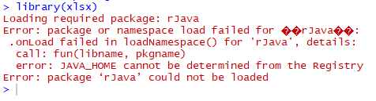

1. 沒有安裝java ，[下載網址](http://www.oracle.com/technetwork/java/javase/downloads/index.html)
2. r 找不道 java 路徑。

[資料下載](https://oscar82722.github.io/Rbasic/testdata.xlsx)

```r
Sys.setenv(JAVA_HOME='C:\\Program Files\\Java\\jre-9.0.1') #java 目錄位置
library(xlsx)
dat.1 <- read.xlsx("C:\\Users\\biostat1142\\Desktop\\r教學資料\\testdata.xlsx",sheetIndex="test1")
dat.1[1:5,]
```

```
##        date                                               var1
## 1 101/02/01                        \xe8\xe7蝘飛摮貊\xa7\x91
## 2 100/08/01                             \xe7\x94\x90飛蝘\x91
## 3 100/08/01                             \xe7\x94\x90飛蝘\x91
## 4 101/02/01 \xe9摮豢炎撽\xe7\x94\xe6\x8a\u0080銵飛蝟\xbb
## 5 101/04/16                                  隤脣\x8b\xb5\x84
##                           var2
## 1            \xe6\x95\x8e\x88
## 2                        雓葦
## 3 \xe5\x90亳\xe6\x95\x8e\x88
## 4         \xe6\x8a\u0080憯\xab
## 5                         蝯
```

```r
dat.2 <- read.xlsx("C:\\Users\\biostat1142\\Desktop\\r教學資料\\testdata.xlsx",sheetIndex="test1",fileEncoding="utf-8");dat.2[1:5,]
```

```
##        date                                               var1
## 1 101/02/01                        \xe8\xe7蝘飛摮貊\xa7\x91
## 2 100/08/01                             \xe7\x94\x90飛蝘\x91
## 3 100/08/01                             \xe7\x94\x90飛蝘\x91
## 4 101/02/01 \xe9摮豢炎撽\xe7\x94\xe6\x8a\u0080銵飛蝟\xbb
## 5 101/04/16                                  隤脣\x8b\xb5\x84
##                           var2 fileEncoding
## 1            \xe6\x95\x8e\x88        utf-8
## 2                        雓葦        utf-8
## 3 \xe5\x90亳\xe6\x95\x8e\x88        utf-8
## 4         \xe6\x8a\u0080憯\xab        utf-8
## 5                         蝯        utf-8
```

```r
dat.3 <- as.data.frame(lapply(dat.2,iconv,from="utf-8",to="big-5")); dat.3[1:5,]
```

```
##        date                   var1     var2 fileEncoding
## 1 101/02/01           藥物科學學科     教授        utf-8
## 2 100/08/01               生理學科     講師        utf-8
## 3 100/08/01               生理學科 名譽教授        utf-8
## 4 101/02/01 醫學檢驗暨生物技術學系     技士        utf-8
## 5 101/04/16                 課務組     組員        utf-8
```

# 4.常用資料處理函數(Data Cleansing)

## 4.1 排序(sort,rank,order)

sort(x) : 回傳排序完的值

rank(x) : 回傳元素對應排名

order(x) : 回傳對應“排名”的元素所在向量中的位置

```r
x <- c(-1,5,3,2,-5)
names(x) <- c("A1","A2","A3","A4","A5")
sort(x)
```

```
## A5 A1 A4 A3 A2
## -5 -1  2  3  5
```

```r
rank(x)
```

```
## A1 A2 A3 A4 A5
##  2  5  4  3  1
```

```r
order(x)
```

```
## [1] 5 1 4 3 2
```

### sort

```r
x <- c(-1,2,-3,5,NA,4)
sort(x); sort(x,decreasing = T)
```

```
## [1] -3 -1  2  4  5
```

```
## [1]  5  4  2 -1 -3
```

```r
sort(x,na.last=F)
```

```
## [1] NA -3 -1  2  4  5
```

### rank

```r
x <- c(NA,-1,2,-3,5,4)
rank(x)
```

```
## [1] 6 2 3 1 5 4
```

```r
y <- c(1,2,1,3,5)
rank(y); rank(y,ties.method="first")
```

```
## [1] 1.5 3.0 1.5 4.0 5.0
```

```
## [1] 1 3 2 4 5
```

### order

```r
name <- paste("A",1:5,sep=""); score <- c(60,63,67,65,70)
order(score)
```

```
## [1] 1 2 4 3 5
```

```r
name[order(score)]
```

```
## [1] "A1" "A2" "A4" "A3" "A5"
```

```r
name[order(score,decreasing = T)]
```

```
## [1] "A5" "A3" "A4" "A2" "A1"
```

```r
names(score) <- name
names(sort(score))
```

```
## [1] "A1" "A2" "A4" "A3" "A5"
```

### 練習(8)

1. 下載檔案，並讀進R 裡。 [人口檔案](https://oscar82722.github.io/test/r_people.csv)

2. 找出土地面積前五名是多大。
3. 找出男性人口最少的五個區域
4. 找出人口密度前五名的區域 (人口密度= 總人口數/土地面積)

```
## 土地前五大為: 4628.57 4106.44 3515.25 2951.85 2775.6 (平方公里)
```

```
## 男性人口最少的五個區域為: 澎湖縣 臺東縣 嘉義市 花蓮縣 基隆市
```

```
## 人口密度前五名的區域為: 臺北市 嘉義市 新竹市 基隆市 新北市
```

## 4.2 資料合併與分割(merge,split,subset)

### 列合併與行合併(rbind,cbind)

```r
id <- paste("A",1:5,sep="")
score1 <- round(rnorm(5,60,1))
data1 <- data.frame(id,score1)
data1
```

```
##   id score1
## 1 A1     59
## 2 A2     60
## 3 A3     59
## 4 A4     61
## 5 A5     61
```

```r
id <- paste("A",6:8,sep="")
score1 <- round(rnorm(3,60,1))
data2 <- data.frame(id,score1)
data2
```

```
##   id score1
## 1 A6     60
## 2 A7     60
## 3 A8     60
```

```r
data.1.2 <- rbind(data1,data2); data.1.2
```

```
##   id score1
## 1 A1     59
## 2 A2     60
## 3 A3     59
## 4 A4     61
## 5 A5     61
## 6 A6     60
## 7 A7     60
## 8 A8     60
```

```r
score2 <- rnorm(8,70,3)
score3 <- rnorm(8,65,5)
data3 <- data.frame(score2,score3)
data3
```

```
##     score2   score3
## 1 70.39425 65.31823
## 2 75.40099 75.92552
## 3 62.36227 66.14351
## 4 66.96412 63.44378
## 5 66.12015 61.33137
## 6 72.11332 66.86809
## 7 67.60623 72.36852
## 8 67.09668 75.33170
```

```r
data.1.2.3 <- cbind(data.1.2,data3); data.1.2.3
```

```
##   id score1   score2   score3
## 1 A1     59 70.39425 65.31823
## 2 A2     60 75.40099 75.92552
## 3 A3     59 62.36227 66.14351
## 4 A4     61 66.96412 63.44378
## 5 A5     61 66.12015 61.33137
## 6 A6     60 72.11332 66.86809
## 7 A7     60 67.60623 72.36852
## 8 A8     60 67.09668 75.33170
```

```r
data <- data.frame(data.1.2,data3);data
```

```
##   id score1   score2   score3
## 1 A1     59 70.39425 65.31823
## 2 A2     60 75.40099 75.92552
## 3 A3     59 62.36227 66.14351
## 4 A4     61 66.96412 63.44378
## 5 A5     61 66.12015 61.33137
## 6 A6     60 72.11332 66.86809
## 7 A7     60 67.60623 72.36852
## 8 A8     60 67.09668 75.33170
```

### merge

case1.

```r
id <- paste("A",1:5,sep="")
score1 <- round(rnorm(5,60,1))
data1 <- data.frame(id,score1)
data1
```

```
##   id score1
## 1 A1     61
## 2 A2     58
## 3 A3     59
## 4 A4     59
## 5 A5     59
```

```r
id <- paste("A",1:5,sep="")
score2 <- round(rnorm(5,60,1))
data2 <- data.frame(id,score2)
data2
```

```
##   id score2
## 1 A1     61
## 2 A2     59
## 3 A3     59
## 4 A4     60
## 5 A5     60
```

```r
merge(data1,data2,by="id")
```

```
##   id score1 score2
## 1 A1     61     61
## 2 A2     58     59
## 3 A3     59     59
## 4 A4     59     60
## 5 A5     59     60
```

```r
id <- paste("A",1:5,sep="")
score1 <- round(rnorm(5,60,1))
data1 <- data.frame(id,score1)
data1
```

```
##   id score1
## 1 A1     61
## 2 A2     60
## 3 A3     58
## 4 A4     61
## 5 A5     60
```

```r
id <- paste("A",1:3,sep="")
score2 <- round(rnorm(3,60,1))
data2 <- data.frame(id,score2)
data2
```

```
##   id score2
## 1 A1     62
## 2 A2     60
## 3 A3     58
```

```r
merge(data1,data2,by="id")
```

```
##   id score1 score2
## 1 A1     61     62
## 2 A2     60     60
## 3 A3     58     58
```

```r
merge(data1,data2,by="id",all=T)
```

```
##   id score1 score2
## 1 A1     61     62
## 2 A2     60     60
## 3 A3     58     58
## 4 A4     61     NA
## 5 A5     60     NA
```

case2.

```r
id <- paste("A",1:3,sep="")
score1 <- round(rnorm(3,60,1))
data1 <- data.frame(id,score1)
data1
```

```
##   id score1
## 1 A1     59
## 2 A2     60
## 3 A3     59
```

```r
id <- paste("A",2:4,sep="")
score2 <- round(rnorm(3,60,1))
data2 <- data.frame(id,score2)
data2
```

```
##   id score2
## 1 A2     61
## 2 A3     61
## 3 A4     59
```

```r
merge(data1,data2,by="id",all=T)
```

```
##   id score1 score2
## 1 A1     59     NA
## 2 A2     60     61
## 3 A3     59     61
## 4 A4     NA     59
```

```r
merge(data1,data2,by="id",all.x =T)
```

```
##   id score1 score2
## 1 A1     59     NA
## 2 A2     60     61
## 3 A3     59     61
```

```r
merge(data1,data2,by="id",all.y =T)
```

```
##   id score1 score2
## 1 A2     60     61
## 2 A3     59     61
## 3 A4     NA     59
```

case3.

```r
id <- paste("A",1:5,sep="")
score1 <- round(rnorm(5,60,1))
data1 <- data.frame(id,score1)
data1
```

```
##   id score1
## 1 A1     60
## 2 A2     60
## 3 A3     60
## 4 A4     59
## 5 A5     58
```

```r
id_number <- paste("A",1:5,sep="")
score2 <- round(rnorm(5,60,1))
data2 <- data.frame(id_number,score2)
data2
```

```
##   id_number score2
## 1        A1     59
## 2        A2     61
## 3        A3     60
## 4        A4     63
## 5        A5     59
```

```r
merge(data1,data2,by.x="id",by.y="id_number")
```

```
##   id score1 score2
## 1 A1     60     59
## 2 A2     60     61
## 3 A3     60     60
## 4 A4     59     63
## 5 A5     58     59
```

case4.

```r
id <- paste("A",rep(c(1,2),each=2),sep="")
class_name <- rep(c("A","B"),2)
data1 <- data.frame(id,class_name)
data1
```

```
##   id class_name
## 1 A1          A
## 2 A1          B
## 3 A2          A
## 4 A2          B
```

```r
id_number <- paste("A",rep(c(1,2,3),2),sep="")
class_name <- rep(c("A","B"),each=3)
score <- rnorm(6,70,1)
data2 <- data.frame(id_number,class_name,score)
data2
```

```
##   id_number class_name    score
## 1        A1          A 71.13969
## 2        A2          A 69.69806
## 3        A3          A 70.91047
## 4        A1          B 68.54941
## 5        A2          B 69.39369
## 6        A3          B 69.72591
```

```r
merge(data1,data2,by.x="id",by.y="id_number")
```

```
##   id class_name.x class_name.y    score
## 1 A1            A            A 71.13969
## 2 A1            A            B 68.54941
## 3 A1            B            A 71.13969
## 4 A1            B            B 68.54941
## 5 A2            A            A 69.69806
## 6 A2            A            B 69.39369
## 7 A2            B            A 69.69806
## 8 A2            B            B 69.39369
```

```r
merge(data1,data2,by.x=c("id","class_name"),by.y=c("id_number","class_name"))
```

```
##   id class_name    score
## 1 A1          A 71.13969
## 2 A1          B 68.54941
## 3 A2          A 69.69806
## 4 A2          B 69.39369
```